# Some Sample Data

## The American National Elections Survey

[figure not shown]

How do we understand elections in America? One source of information that you have probably seen on television and the internet are national surveys from news agencies and polling companies. One of the largest surveys, though, comes out of the University of Michigan called the American National Election Survey. This is the primary means that academic researchers test theories of political behavior and because it is done after elections as well, it can tell about who voters actually voted for and not just who they think they’ll vote for weeks before an election.

Take this question for example, which is designed to gauge how political informed someone is:

> Some people seem to follow what’s going on in government and public affairs most of the time, whether there’s an election going on or not. Others aren’t that interested. Would you say you follow what’s going on in government and public affairs most of the time, some of the time, only now and then, or hardly at all?

The respondent is given four possible responces:

- Most of the time [1]
- Some of the time [2]
- Only now and then [3]
- Hardly at all [4]

So those on the lower end of the scale (1 and 2) are actually the most politically informed and the higher end (3 and 4) are the least informed – assuming that following news conveys information.

When we look at the data inside of the spreadsheet, the responces are stored as numbers and it is important that you interpret them.

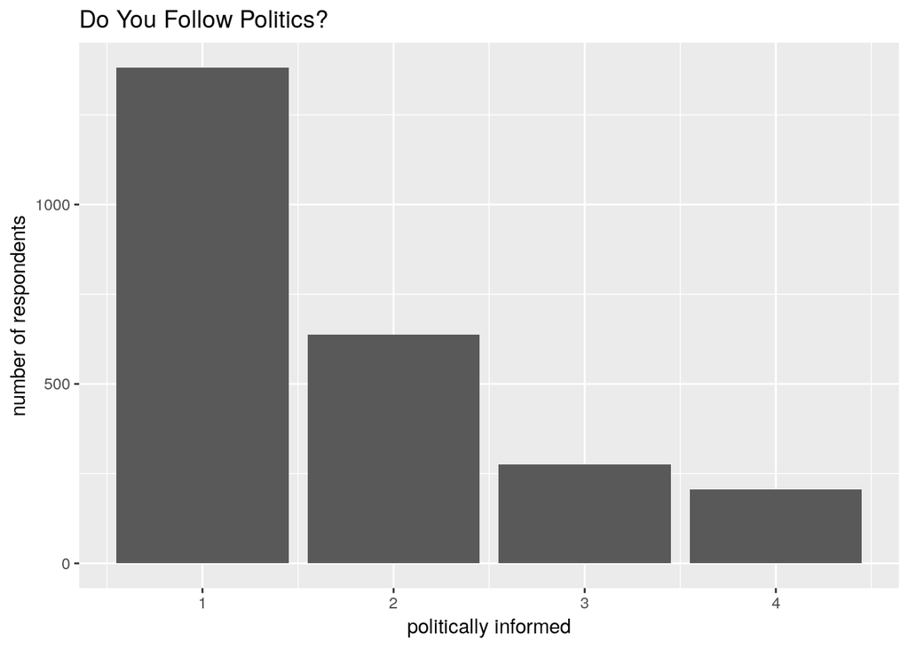

## Discussion Questions

- According to the barplot of the answers, are most respondents well-informed or not well-informed?
- Is the description of the “follow” variable appropriate? How would you interpret the graph without labels?

## More Data Sets

Data comes in many forms and it isn’t always easy to access. That said, there are many sources on the web that will allow you to look at information that might appeal to you. Check [this](https://github.com/awesomedata/awesome-public-datasets#transportation) website for some more samples!